# Chapter 3

## Conceptual

### Excercise 1

Intercept:  
$H_0$: Intercept term = 0, given any combinations of coefficients of TV, Radio and Newspaper.  
Conclusion: Without any advertising of TV, Radio, and Newspaper, sales is approximately 2939 units.

TV:  
$H_0$: TV coefficient = 0, given fixed coefficients of Radio and Newspaper.  
Conclusion: Given certain amount of Radio and Newspaper advertising, spending an additional $1,000 in TV advertising leads to an increase in sales by approximately 46 units.

Radio:  
$H_0$: Radio coefficient = 0, given fixed coefficients of TV and Newspaper.  
Conclusion: Given certain amount of TV and Newspaper advertising, spending an additional $1,000 in Radio advertising leads to an increase in sales by approximately 189 units.

Newspaper:  
$H_0$: Newspaper coefficient = 0, given fixed coefficients of TV and Radio.  
Conclusion: Given certain amount of TV and Radio advertising, there is no relationship between Newspaper advertising and sales.

### Excercise 2

| Explanation | KNN Classifier | KNN Regression |
| --- | --- | --- |
| Math | $\mathop {max}\limits_j \Pr (Y = j\|X = {X_0}) = \frac{1}{K}\sum\limits_{i \in {N_0}} {I({y_i} = j)}$ | $\hat f({x_0}) = \frac{1}{K}\sum\limits_{i \in {N_0}} {{y_i}}$ |
| Math Explanation | By using indicator function, KNN Classifier statistically analyzes classes of neighborhood points and picks up the class with largest proportion where the probability of certain class to test data is … | KNN Regression calculates the average of responses of neighborhood points and treats that average as the expectation of regression model. |
| Usage | Qualitative (categorical) data | Quantitative data |

### Excercise 3a

[output not shown]

| Male | Female |
| --- | --- |
| $50 + 0.07 \times {\rm{IQ}} + (20 + 0.01 \times {\rm{IQ}}) \times {\rm{GPA}}$ | $0.07 \times {\rm{IQ}} + 50 + (10 + 0.01 \times {\rm{IQ}}) \times {\rm{GPA}} + 35$ |
| $(20 + 0.01 \times {\rm{IQ}}) \times {\rm{GPA}}$ | $(10 + 0.01 \times {\rm{IQ}}) \times {\rm{GPA}} + 35$ |

Provided that GPA is high enough, lhs will be greater than rhs, i.e., on average, males earn more than females.  
iv. Incorrect

### Excercise 3b

$\begin{array}{l} Y & = & 50 + (20 - 10 \times {\rm{Gender}} + 0.01 \times {\rm{IQ}} \times {\rm{GPA}} + 0.07 \times {\rm{IQ}} + 35 \times {\rm{Gender}}\\ & = & 50 + (20 - 10 + 0.01 \times 110) \times 4.0 + 0.07 \times 110 + 35\\ & = & 137.1 \end{array}$

### Excercise 3c

Evidence of interaction does not depend on the magnitude of coefficient of the interaction term, rather it depends on whether corresponding p-value is smaller than the cutoff value. However, magnitude of coefficient of the interaction term indicates the effect of interaction.

### Excercise 4

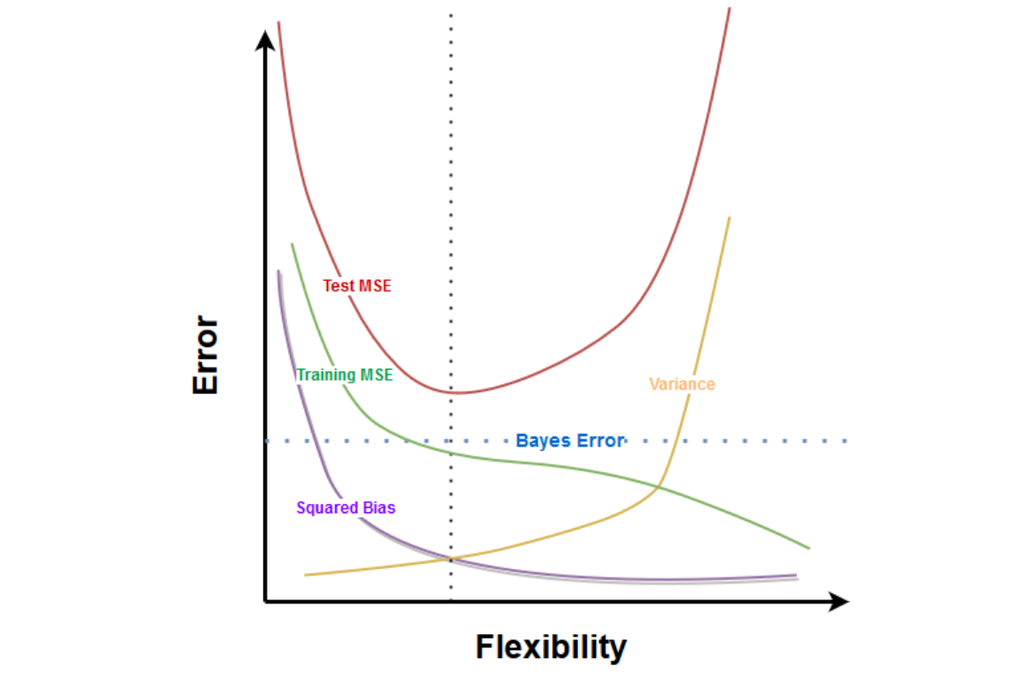

### Excercise 4b

We would expect test RSS for the linear regression smaller than one for the linear regression. Since the true relationship is linear, fitting the data using cubic regression will bring unnecessary complexity thus resulting in high variance, by which the test error can be high.

### Excercise 4c

Still, we would expect training RSS for the cubic regression smaller than the one for linear regression, cause training error will decrease as the flexibility increases.

### Excercise 4d

There is not enough information to tell. Because test RSS is a U-shape curve versus model flexibility. Since we don’t know how far the true relationship is from linear, it is possible that test RSS with high flexibility model is higher, lower, or even same with the one of linear regression.

### Excercise 5

Since ${\hat y_i} = {x_i}\hat \beta$, where $\hat \beta = \frac{{\sum\limits_{i = 1}^n {{x_i}{y_i}} }}{{\sum\limits_{i' = 1}^n {x_{i'}^2} }}$.

Therefore, we have: ${\hat y_t} = {x_t}\hat \beta = {x_t}\frac{{\sum\limits_{i = 1}^n {{{x'}_i}{{y'}_i}} }}{{\sum\limits_{k = 1}^n {x_k^2} }} = \frac{{\sum\limits_{i = 1}^n {{{x'}_i}{x_t}} }}{{\sum\limits_{k = 1}^n {x_k^2} }}{y'_i}$

and, ${\hat y_i} = \sum\limits_{i = 1}^n {{a_i}{{y'}_i}} = \sum\limits_{i = 1}^n {\frac{{{{x'}_i}{x_t}}}{{\sum\limits_{k = 1}^n {x_k^2} }}{{y'}_i}}$

So, ${a_i} = \frac{{{{x'}_i}{x_t}}}{{\sum\limits_{k = 1}^n {x_k^2} }}{y'_i}$

### Excercise 6

${\hat \beta _1}{\kern 1pt} = \frac{{\sum\nolimits_{i = 1}^n {({x_i} - \bar x)} ({y_i} - \bar y)}}{{{{\sum\nolimits_{i = 1}^n {({x_i} - \bar x)} }^2}}}$

${\hat \beta _0}{\kern 1pt} = \bar y - {\hat \beta _1}{\kern 1pt} \bar x$

If ${x_i} = \bar x$, then ${y_i} = {\hat \beta _0} + {\hat \beta _1}{\kern 1pt} {x_i} = (\bar y - {\hat \beta _1}{\kern 1pt} \bar x) + {\hat \beta _1}\bar x = \bar y$

Therefore, Therefore, line of simple linear regression must pass through point $(\bar x,\bar y)$.

### Excercise 7

Correlation is defined as: ${\rm{Cor}}(X,Y) = \frac{{\sum\nolimits_{i = 1}^n {({x_i} - \bar x)({y_i} - \bar y)} }}{{\sqrt {\sum\nolimits_{i = 1}^n {{{({x_i} - \bar x)}^2}{{({y_i} - \bar y)}^2}} } }}$

And R^2 is defined as: ${\rm{RSS}} = \sum\limits_{i = 1}^n {{{({y_i} - {{\hat y}_i})}^2}}, {\rm{TSS}} = \sum\limits_{i = 1}^n {{{({y_i} - \bar y)}^2}}$

${{\rm{R}}^{\rm{2}}} = \frac{{{\rm{TSS}} - {\rm{RSS}}}}{{{\rm{TSS}}}} = 1 - \frac{{\sum\limits_{i = 1}^n {{{({y_i} - {{\hat y}_i})}^2}} }}{{\sum\limits_{i = 1}^n {{{({y_i} - \bar y)}^2}} }}$

${\rm{RSS}} = \sum\limits_{i = 1}^n {{{({y_i} - {{\hat y}_i})}^2}} = \sum\limits_{i = 1}^n {{{(a{x_i} + b - {y_i})}^2}}$

Let’s denote $g(a,b) = \sum\limits_{i = 1}^n {{{(a{x_i} + b - {y_i})}^2}}$.

We’ve discovered that the loss is optimized at $g(1,0)$.

Take derivatives of $g$ at $(1,0)$, we have: $\begin{array}{l} \frac{\partial }{{\partial a}}g{(a,b)_{(a = 1,b = 0)}} & = & \sum\limits_{i = 1}^n {2(a{x_i} + b - {y_i})} {x_i}\\ & = & \sum\limits_{i = 1}^n {2({x_i} - {y_i})} {x_i}\\ & = & 0 \end{array}$

$\begin{array}{l} \frac{\partial }{{\partial b}}g{(a,b)_{(a = 1,b = 0)}} & = & \sum\limits_{i = 1}^n {2(a{x_i} + b - {y_i})} \\ & = & \sum\limits_{i = 1}^n {2({x_i} - {y_i})} \\ & = & 0 \end{array}$

From the partial with respect to $a$, we get ${x_i}{x_i} = {y_i}{x_i}$

From the partial with respect to $b$, we get ${x_i} = {y_i}$

Here, we can also deduce that ${\hat y_i} = a{x_i} + b = {x_i}$.

For simplicity, we shift the coordinate system so that $\bar x = 0$ and $\bar y = 0$, therefore, we have $\begin{array}{l} {{\rm{R}}^{\rm{2}}} & = & 1 - \frac{{\sum\limits_{i = 1}^n {{{({y_i} - {{\hat y}_i})}^2}} }}{{\sum\limits_{i = 1}^n {{{({y_i} - \bar y)}^2}} }} = 1 - \frac{{\sum\limits_{i = 1}^n {y_i^2 + \hat y_i^2 - 2{y_i}{{\hat y}_i}} }}{{\sum\limits_{i = 1}^n {y_i^2} }}\\ & = & 1 - \frac{{\sum\limits_{i = 1}^n {y_i^2 + x_i^2 - 2{y_i}{x_i}} }}{{\sum\limits_{i = 1}^n {y_i^2} }}\\ & = & 1 - \frac{{\sum\limits_{i = 1}^n {y_i^2 - {x_i}{x_i}} }}{{\sum\limits_{i = 1}^n {y_i^2} }}\\ & = & \frac{{\sum\limits_{i = 1}^n {{x_i}{x_i}} }}{{\sum\limits_{i = 1}^n {y_i^2} }} \end{array}$

$\begin{array}{l} {\rm{Cor}}(X,Y) & = & \frac{{\sum\nolimits_{i = 1}^n {{x_i}{y_i}} }}{{\sqrt {\sum\nolimits_{i = 1}^n {{x_i}^2{y_i}^2} } }} = \frac{{\sum\nolimits_{i = 1}^n {{x_i}{x_i}} }}{{\sqrt {\sum\nolimits_{i = 1}^n {{y_i}^2{y_i}^2} } }}\\ & = & \frac{{\sum\nolimits_{i = 1}^n {{x_i}{x_i}} }}{{\sqrt {\sum\nolimits_{i = 1}^n {{x_i}{x_i}{y_i}{y_i}} } }}\\ & = & \sqrt {\frac{{\sum\nolimits_{i = 1}^n {{x_i}{x_i}} }}{{\sum\nolimits_{i = 1}^n {{y_i}{y_i}} }}} \end{array}$

As we can see, ${{\rm{R}}^2} = \frac{{\sum\limits_{i = 1}^n {{x_i}{x_i}} }}{{\sum\limits_{i = 1}^n {y_i^2} }} = {\sqrt {\frac{{\sum\nolimits_{i = 1}^n {{x_i}{x_i}} }}{{\sum\nolimits_{i = 1}^n {{y_i}{y_i}} }}} ^2} = {\rm{Cor}}{(X,Y)^2}$

## Applied

### Excercise 8a

```r
library(ISLR)
attach(Auto)
lm.fit = lm(mpg~horsepower)
summary(lm.fit)
```

```
##
## Call:
## lm(formula = mpg ~ horsepower)
##
## Residuals:
##      Min       1Q   Median       3Q      Max
## -13.5710  -3.2592  -0.3435   2.7630  16.9240
##
## Coefficients:
##              Estimate Std. Error t value Pr(>|t|)
## (Intercept) 39.935861   0.717499   55.66   <2e-16 ***
## horsepower  -0.157845   0.006446  -24.49   <2e-16 ***
## ---
## Signif. codes:  0 '***' 0.001 '**' 0.01 '*' 0.05 '.' 0.1 ' ' 1
##
## Residual standard error: 4.906 on 390 degrees of freedom
## Multiple R-squared:  0.6059, Adjusted R-squared:  0.6049
## F-statistic: 599.7 on 1 and 390 DF,  p-value: < 2.2e-16
```

1. There is a relationship between mpg and horsepower, since the p-value is less than 2e-16.
2. The relationship is quite strong cause the p-value is nearly zero, which indicates that the probability of obversing ${\beta _{{\rm{horsepower}}}} = -0.158$ or more extreme cases is nearly zero, provided that ${\beta _{{\rm{horsepower}}}} = 0$.
3. Negative, becasue $-0.158 < 0$.
4. Given ${{\rm{horsepower}}} = 98$, its prediction value is

```r
predict(lm.fit, data.frame(horsepower = c(98)))
```

```
##        1
## 24.46708
```

Also, the corresponding confidence and prediction interval can be calculated as

```r
predict(lm.fit, data.frame(horsepower = (c(98))), interval = "confidence")
```

```
##        fit      lwr      upr
## 1 24.46708 23.97308 24.96108
```

```r
predict(lm.fit, data.frame(horsepower = (c(98))), interval = "prediction")
```

```
##        fit     lwr      upr
## 1 24.46708 14.8094 34.12476
```

### Excercise 8b

Regression line is drawn using

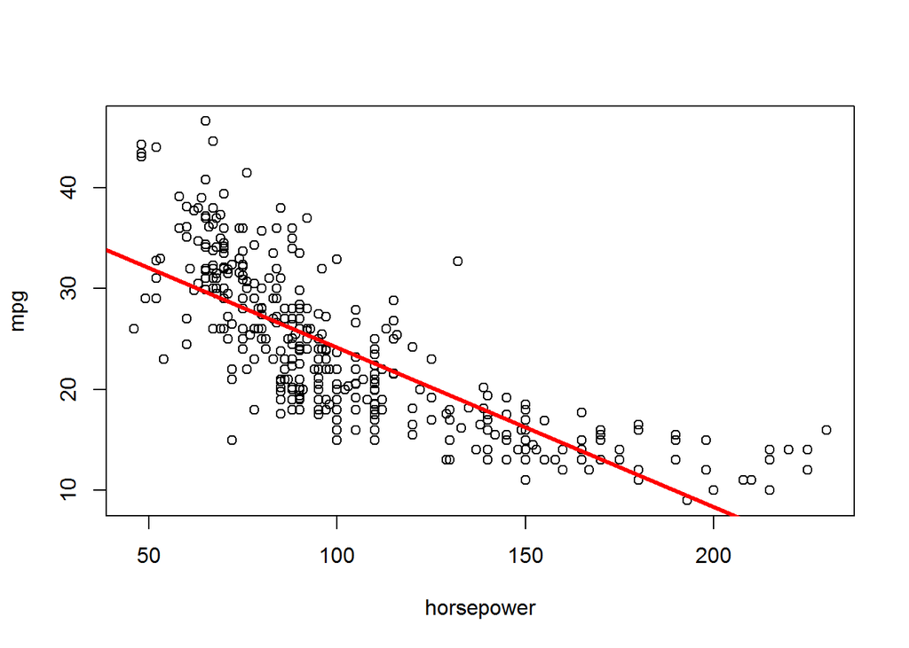

```r
plot(horsepower, mpg)
abline(lm.fit, lwd = 3, col = "red")
```